# PS3_q1

Aastha

3/25/2020

```r
library(tidyverse)
library(readr)
library(ks)
library(kdensity)
library(data.table)
library(fitdistrplus)
library(ggplot2)
library(gridExtra)
library(ggpubr)
library(dvmisc)
library(polywog)
library(splines)
library(freeknotsplines)
library(foreign)
library(MatchIt)
library(dplyr)
library(cem)
library(jtools)
#library(rstatix)
setwd("~/github/empirical-methods/ProblemSets/pset3")
```

Loading DW’s version of data.

```r
data_dw <- read.dta("nsw_dw.dta")
```

## Ques 1

Checking for balance across the treatment and control group in the DW sample.

```r
age <- data_dw$age
treat <- data_dw$treat
black <- data_dw$black
hispanic <- data_dw$hispanic
education <- data_dw$education
married <- data_dw$married
nodegree <- data_dw$nodegree
re74 <- data_dw$re74
re78 <- data_dw$re78
re75 <- data_dw$re75

#mean(age[treat == 1])
#mean(age[treat == 0])

# calculating means by treatment status (control == 0, treatment == 1)

covars<- c('age', 'married', 'education', 'black', 'hispanic', 'nodegree', 're74', 're75')
data_dw %>%
  group_by(treat) %>%
  dplyr::select(one_of(covars)) %>%
  summarise_all(funs(mean(., na.rm = T)))
```

```
## # A tibble: 2 x 9
##   treat   age married education black hispanic nodegree  re74  re75
##   <dbl> <dbl>   <dbl>     <dbl> <dbl>    <dbl>    <dbl> <dbl> <dbl>
## 1     0  25.1   0.154      10.1 0.827   0.108     0.835 2107. 1267.
## 2     1  25.8   0.189      10.3 0.843   0.0595    0.708 2096. 1532.
```

```r
# Testing for difference in means to check if the data is balanced or not.

lapply(data_dw[,c("married", "age", "black", "nodegree", "hispanic", "education", "re74", "re75")], function(x) t.test(x ~ data_dw$treat, var.equal = TRUE))
```

```
## $married
##
##  Two Sample t-test
##
## data:  x by data_dw$treat
## t = -0.98043, df = 443, p-value = 0.3274
## alternative hypothesis: true difference in means is not equal to 0
## 95 percent confidence interval:
##  -0.10619023  0.03550416
## sample estimates:
## mean in group 0 mean in group 1
##       0.1538462       0.1891892
##
##
## $age
##
##  Two Sample t-test
##
## data:  x by data_dw$treat
## t = -1.1166, df = 443, p-value = 0.2648
## alternative hypothesis: true difference in means is not equal to 0
## 95 percent confidence interval:
##  -2.1042036  0.5794635
## sample estimates:
## mean in group 0 mean in group 1
##        25.05385        25.81622
##
##
## $black
##
##  Two Sample t-test
##
## data:  x by data_dw$treat
## t = -0.45478, df = 443, p-value = 0.6495
## alternative hypothesis: true difference in means is not equal to 0
## 95 percent confidence interval:
##  -0.08684845  0.05420811
## sample estimates:
## mean in group 0 mean in group 1
##       0.8269231       0.8432432
```

[output cut: 55 more lines]

```
##        2107.027        2095.574
##
##
## $re75
##
##  Two Sample t-test
##
## data:  x by data_dw$treat
## t = -0.87462, df = 443, p-value = 0.3823
## alternative hypothesis: true difference in means is not equal to 0
## 95 percent confidence interval:
##  -860.9479  330.6553
## sample estimates:
## mean in group 0 mean in group 1
##        1266.909        1532.055
```

Yes, the means are balanced (except the ‘no degree’ variable), the numbers reported for control (treat == 0) and treatment (treat == 1) are the same as table 1 of the paper.

## Ques 2

Estimating the main treatment effet of the training program on 1978 earnings (`re78`)

```r
treatEff_b <- mean(re78[treat == 1]) - mean(re78[treat == 0])
treatEff_b
```

```
## [1] 1794.342
```

```r
reg1 <- lm (re78 ~ age + education + black + hispanic + married + nodegree + treat
            + re74 + re75)

summ(reg1, model.info = FALSE, digits = 3)
```

```
## MODEL FIT:
## F(9,435) = 2.804, p = 0.003
## R² = 0.055
## Adj. R² = 0.035
##
## Standard errors: OLS
## ---------------------------------------------------------
##                          Est.       S.E.   t val.       p
## ----------------- ----------- ---------- -------- -------
## (Intercept)           785.061   3374.969    0.233   0.816
## age                    55.317     45.284    1.222   0.223
## education             395.734    227.415    1.740   0.083
## black               -2159.522   1169.036   -1.847   0.065
## hispanic              164.033   1549.457    0.106   0.916
## married              -138.725    879.728   -0.158   0.875
## nodegree              -70.681   1004.387   -0.070   0.944
## treat                1676.343    638.682    2.625   0.009
## re74                    0.082      0.077    1.061   0.289
## re75                    0.053      0.135    0.389   0.697
## ---------------------------------------------------------
```

```r
reg2 <- lm (re78 ~ age + I(age^2) + education + I(education^2) + nodegree + black + hispanic + re74 + I(re74^2) + re75 + I(re75^2) + married + treat)

summ(reg2, model.info = FALSE, digits = 3)
```

```
## MODEL FIT:
## F(13,431) = 2.385, p = 0.004
## R² = 0.067
## Adj. R² = 0.039
##
## Standard errors: OLS
## ------------------------------------------------------------
##                             Est.       S.E.   t val.       p
## -------------------- ----------- ---------- -------- -------
## (Intercept)             5064.013   6558.714    0.772   0.440
## age                      167.213    273.908    0.610   0.542
## I(age^2)                  -2.064      4.498   -0.459   0.647
## education              -1136.235   1239.305   -0.917   0.360
## I(education^2)            87.551     69.357    1.262   0.208
## nodegree                 759.465   1225.582    0.620   0.536
## black                  -2184.626   1171.067   -1.866   0.063
## hispanic                 216.235   1554.923    0.139   0.889
## re74                      -0.221      0.174   -1.273   0.204
## I(re74^2)                  0.000      0.000    1.887   0.060
## re75                       0.339      0.261    1.296   0.196
## I(re75^2)                 -0.000      0.000   -0.916   0.360
## married                 -219.875    891.043   -0.247   0.805
## treat                   1622.392    641.818    2.528   0.012
## ------------------------------------------------------------
```

Since the treatment was allocated randomly, the treatment effect without covariates is just the difference of the expected value of the outcome variable under treatment minus expected value of outcome variable under control.

The treatment effect with covariates is a linear regression of the outcome variabe on the treatment dummy variable as well as other control variables.

# Ques 3 and 4

Estimating the treatment effect using a different control group from the PSID data.

```r
# dropping NSW control group

Ndata_dw <- data_dw[which(treat == '1'),]
psid_cont <- read.dta("psid_controls.dta")

dim(Ndata_dw)
```

```
## [1] 185  11
```

```r
dim(psid_cont)
```

```
## [1] 2490   11
```

```r
# appending the data with PSID controls
data_dw_psid <- rbind(Ndata_dw, psid_cont)
dim(data_dw_psid)
```

```
## [1] 2675   11
```

```r
age <- data_dw_psid$age
treat <- data_dw_psid$treat
black <- data_dw_psid$black
hispanic <- data_dw_psid$hispanic
education <- data_dw_psid$education
married <- data_dw_psid$married
nodegree <- data_dw_psid$nodegree
re74 <- data_dw_psid$re74
re78 <- data_dw_psid$re78
re75 <- data_dw_psid$re75

# Testing for balance between treatment and control
covars_psid <- c('age', 'married', 'education', 'black', 'hispanic', 'nodegree', 're74', 're75')
data_dw_psid %>%
  group_by(treat) %>%
  dplyr::select(one_of(covars_psid)) %>%
  summarise_all(funs(mean(., na.rm = T)))
```

```
## # A tibble: 2 x 9
##   treat   age married education black hispanic nodegree   re74   re75
##   <dbl> <dbl>   <dbl>     <dbl> <dbl>    <dbl>    <dbl>  <dbl>  <dbl>
## 1     0  34.9   0.866      12.1 0.251   0.0325    0.305 19429. 19063.
## 2     1  25.8   0.189      10.3 0.843   0.0595    0.708  2096.  1532.
```

```r
# testing for difference in means


#lapply(covars_psid, function(v) {
#  t.test(data_dw_psid[, v] ~ data_dw_psid[, 'treat'])
#}) # maybe previous method was nice

lapply(data_dw_psid[,c("married", "age", "black", "nodegree", "hispanic", "education", "re74", "re75")], function(x) t.test(x ~ data_dw_psid$treat, var.equal = TRUE, model.info = FALSE))
```

```
## $married
##
##  Two Sample t-test
##
## data:  x by data_dw_psid$treat
## t = 25.807, df = 2673, p-value < 2.2e-16
## alternative hypothesis: true difference in means is not equal to 0
## 95 percent confidence interval:
##  0.6256307 0.7285211
## sample estimates:
## mean in group 0 mean in group 1
##       0.8662651       0.1891892
##
##
## $age
##
##  Two Sample t-test
##
## data:  x by data_dw_psid$treat
## t = 11.568, df = 2673, p-value < 2.2e-16
## alternative hypothesis: true difference in means is not equal to 0
## 95 percent confidence interval:
##   7.503027 10.565745
## sample estimates:
## mean in group 0 mean in group 1
##        34.85060        25.81622
##
##
## $black
##
##  Two Sample t-test
##
## data:  x by data_dw_psid$treat
## t = -18.126, df = 2673, p-value < 2.2e-16
## alternative hypothesis: true difference in means is not equal to 0
## 95 percent confidence interval:
##  -0.6567527 -0.5285289
## sample estimates:
## mean in group 0 mean in group 1
##       0.2506024       0.8432432
```

[output cut: 55 more lines]

```
##       19428.746        2095.574
##
##
## $re75
##
##  Two Sample t-test
##
## data:  x by data_dw_psid$treat
## t = 17.498, df = 2673, p-value < 2.2e-16
## alternative hypothesis: true difference in means is not equal to 0
## 95 percent confidence interval:
##  15566.68 19495.88
## sample estimates:
## mean in group 0 mean in group 1
##       19063.338        1532.055
```

```r
#library(rstatix)
#stat.test <- data_dw_psid %>%
#  t_test(covars_psid ~ treat) %>%
#  add_significance()
#stat.test
```

Notice that the samples are not balanced across observables in the control versus treatment group. The difference between the mean values of the covariates across the treatment and control group are significantly different, as can be seen by the p-values in the results above. Therefore, after changing the control group to the PSID sample, the treatment and the control groups are no more balanced in the observables.

#Ques 5

Constructing a propensity score for the treatment.

```r
# estimate the propensity score by running a logit model


m_ps <- glm(treat ~ age + education + nodegree + black + hispanic + re74 + re75 + married , family = binomial(), data = data_dw_psid)
summary(m_ps)
```

```
##
## Call:
## glm(formula = treat ~ age + education + nodegree + black + hispanic +
##     re74 + re75 + married, family = binomial(), data = data_dw_psid)
##
## Deviance Residuals:
##     Min       1Q   Median       3Q      Max
## -2.2208  -0.0929  -0.0132  -0.0017   4.0883
##
## Coefficients:
##               Estimate Std. Error z value Pr(>|z|)
## (Intercept)  6.371e-01  1.180e+00   0.540 0.589245
## age         -7.900e-02  1.478e-02  -5.345 9.02e-08 ***
## education    3.981e-02  6.972e-02   0.571 0.568061
## nodegree     7.742e-01  3.528e-01   2.194 0.028226 *
## black        2.200e+00  3.182e-01   6.915 4.67e-12 ***
## hispanic     2.008e+00  5.592e-01   3.591 0.000329 ***
## re74        -1.092e-04  2.913e-05  -3.747 0.000179 ***
## re75        -2.614e-04  4.042e-05  -6.466 1.00e-10 ***
## married     -1.627e+00  2.627e-01  -6.195 5.81e-10 ***
## ---
## Signif. codes:  0 '***' 0.001 '**' 0.01 '*' 0.05 '.' 0.1 ' ' 1
##
## (Dispersion parameter for binomial family taken to be 1)
##
##     Null deviance: 1345.30  on 2674  degrees of freedom
## Residual deviance:  467.62  on 2666  degrees of freedom
## AIC: 485.62
##
## Number of Fisher Scoring iterations: 9
```

```r
# Using this model, we can now calculate the propensity score for observation. It is simply the sample's predicted probability of being Treated, given the estimates from the logit model. Below, I calculate this propensity score using predict() and create a dataframe that has the propensity score as well as the actual treatment status.

prs_df <- data.frame(pr_score = predict(m_ps, type = "response"),
                     treat = m_ps$model$treat)
head(prs_df)
```

```
##    pr_score treat
## 1 0.3773454     1
## 2 0.8849355     1
## 3 0.7201238     1
## 4 0.8717413     1
## 5 0.7896888     1
## 6 0.9030698     1
```

Plotting the propensity score.

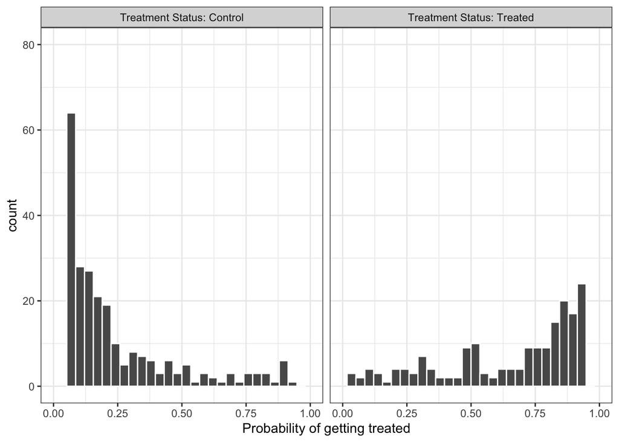

```r
labs <- paste("Treatment Status:", c("Treated", "Control"))
prs_df %>%
  mutate(treat = ifelse(treat == 1, labs[1], labs[2])) %>%
  ggplot(aes(x = pr_score)) +
  geom_histogram(color = "white") +
  facet_wrap(~treat) +
  xlab("Probability of getting treated") + xlim(0,1) + ylim(0,80) +
  theme_bw()
```

Replotting using the specification used in footnote of table 3:

```
##
## Call:
## glm(formula = treat ~ age + I(age^2) + education + I(education^2) +
##     nodegree + black + hispanic + re74 + I(re74^2) + re75 + I(re75^2) +
##     married, family = binomial(), data = data_dw_psid)
##
## Deviance Residuals:
##     Min       1Q   Median       3Q      Max
## -2.2709  -0.0760  -0.0129  -0.0020   4.0137
##
## Coefficients:
##                  Estimate Std. Error z value Pr(>|z|)
## (Intercept)    -7.211e+00  2.316e+00  -3.114 0.001849 **
## age             3.131e-01  1.132e-01   2.766 0.005683 **
## I(age^2)       -5.829e-03  1.736e-03  -3.358 0.000785 ***
## education       7.348e-01  3.142e-01   2.339 0.019336 *
## I(education^2) -4.113e-02  1.637e-02  -2.512 0.011989 *
## nodegree        2.498e-01  3.999e-01   0.625 0.532077
## black           2.062e+00  3.227e-01   6.390 1.66e-10 ***
## hispanic        2.176e+00  5.949e-01   3.657 0.000255 ***
## re74           -1.833e-04  3.453e-05  -5.307 1.11e-07 ***
## I(re74^2)       3.267e-09  5.310e-10   6.152 7.63e-10 ***
## re75           -2.608e-04  4.353e-05  -5.992 2.07e-09 ***
## I(re75^2)       1.804e-10  5.173e-10   0.349 0.727273
## married        -1.816e+00  2.814e-01  -6.455 1.08e-10 ***
## ---
## Signif. codes:  0 '***' 0.001 '**' 0.01 '*' 0.05 '.' 0.1 ' ' 1
##
## (Dispersion parameter for binomial family taken to be 1)
##
##     Null deviance: 1345.30  on 2674  degrees of freedom
## Residual deviance:  437.75  on 2662  degrees of freedom
## AIC: 463.75
##
## Number of Fisher Scoring iterations: 10
```

```
##   pr_score3 treat
## 1 0.4984780     1
## 2 0.9284136     1
## 3 0.8689323     1
## 4 0.9176040     1
## 5 0.9113637     1
## 6 0.9204688     1
```

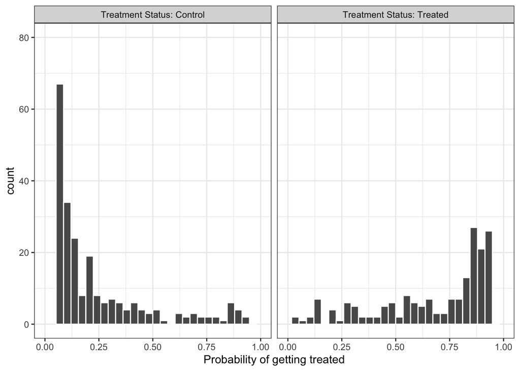